```python
# importing necesarry libraries
import numpy as np
import pandas as pd
import matplotlib.pyplot as plt

%matplotlib inline
plt.rcParams['figure.figsize'] = (10, 8)

# style
# plt.style.use('fivethirtyeight')
plt.style.use("ggplot")

# pulling all info from the csv file provided for the dataset into a dataframe
crime_data = pd.read_csv("Crime_Data_from_2010_to_2019.csv")

# defining method that will be used to get proportions throughout this notebook
def column_proportions(df, col_name, rename):
    """Given a data frame and name of a column, produce a new data frame with values,
    number of occurrences, and  for each value."""
    # number of rows of data frame
    size = len(df)

    # create the data frame with the first two columns
    res = pd.DataFrame({"Total": (df.groupby([col_name])[col_name].count())})

    # make index into a column
    res.reset_index(inplace=True)

    # rename the columns
    res = res.rename(columns={col_name: rename})

    # add Proportions column
    res['Proportion'] = (res['Total']/size)*100

    # sort by total in increasing order (and fix the index)
    res = res.sort_values(by='Total', ascending = False)

    # reset index dropping old
    res = res.reset_index(drop=True)

    return res
```

# Dataset Analysis (Data 301 Project)

**Group Members:**

- Jackson Dodd
- Bailey Friedman

**Description:**

- Our analysis will be over the data repository titled, “Crime Data from 2010 to 2019”. This dataset is an overview of all crime data between 2010 and 2019 in the city of Los Angeles. This data includes all the information from the police report, like where it happened, what happened, as well as when it happened just to name a few things.

**Disclaimers:**

- There is a natural level of bias to police reports, so that will be present in this dataset.
- Some locations with missing field data may have their location marked as (0, 0).
- The scaling of the bar graphs changes, so please look at the percentages for each graph.

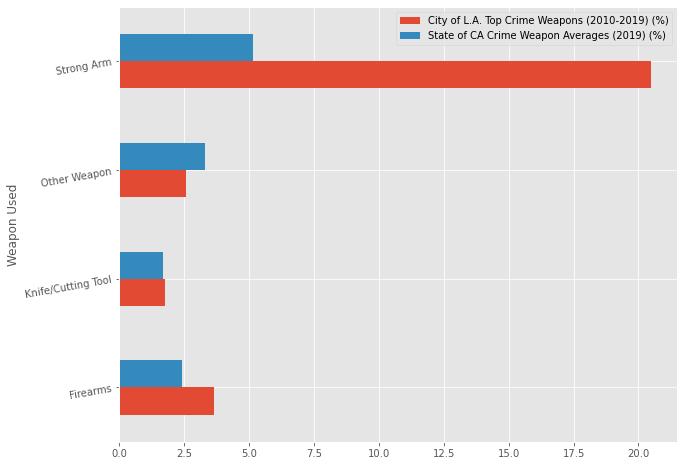

```python
# make initial weapon proportions df using method created earlier
weapon_proportions = column_proportions(crime_data, "Weapon Desc", "Weapon Used")

# store 'strong arm crime' and 'other crime' counts for later
total_arm_crimes = weapon_proportions["Total"][0]
total_other_crimes = weapon_proportions["Total"][2]

# store 'strong arm crime' and 'other crime' proportions for later
percent_arm_crimes = weapon_proportions["Proportion"][0]
percent_other_crimes = weapon_proportions["Proportion"][2]



# Filter crimes for all descriptions fitting knifes/cutting objects
knife_crimes = crime_data["Weapon Desc"].str.contains("KNIFE|CUTTING|SCISSORS|MACHETE|BLADE|AXE|SWORD|ICE PICK|RAZOR|DAGGER|CLEAVER|GLASS|SYRINGE", na=False)
total_knife_crimes = knife_crimes.sum()

# Filter crimes for all descriptions fitting firearms
gun_crimes = crime_data["Weapon Desc"].str.contains("GUN|PISTOL|RIFLE|FIREARM|REVOLVER|SHOTGUN|AK47|SUB-MACHINE GUN|MAC-10" , na=False)
total_gun_crimes = gun_crimes.sum()

# SIMULATED GUN	437 (so fake gun)
total_gun_crimes = total_gun_crimes-437

# AIR PISTOL/REVOLVER/RIFLE/BB GUN	208 (so fake gun)
total_gun_crimes = total_gun_crimes-208

# make initial template for top 4 weapons used
top_crimes = column_proportions(crime_data, "Weapon Desc", "Weapon Used").head(4).copy(deep=False)

# renames weapon used full descriptors to weapon groups we're comparing
a1D = np.array(["Strong Arm", "Firearms", "Other Weapon", "Knife/Cutting Tool"])
top_crimes["Weapon Used"] = a1D

# reasigns totals to general categories totals
a1D = np.array([total_arm_crimes, total_gun_crimes, total_other_crimes, total_knife_crimes])
top_crimes["Total"] = a1D

# reasigns Proportions to general categories proportions
a1D = np.array([(total_arm_crimes/191488)*100, (total_gun_crimes/191488)*100, (total_other_crimes/191488)*100, (total_knife_crimes/191488)*100])
top_crimes["Proportion"] = a1D



# makes a copy of the data frame for the top CA crimes
top_CA_crimes = top_crimes.copy(deep=False)

# makes proportions the crime category percentages of the full state of California
# from the California Dept. of Justice data from 2019. - Cited below
firearm_crimes_CA_percent = ((12414+17748)/1246700)*100
knife_crimes_CA_percent = ((4719+16413)/1246700)*100
other_crimes_CA_percent = ((6068+35093)/1246700)*100
strong_arm_crimes_CA_percent = ((28849+35502)/1246700)*100
a1D = np.array([strong_arm_crimes_CA_percent, firearm_crimes_CA_percent, other_crimes_CA_percent, knife_crimes_CA_percent])
top_CA_crimes["Proportion"] = a1D
top_CA_crimes

# joins data frames together to be graphed together
crime_comparison = ((top_crimes.join(top_CA_crimes, rsuffix=' (of CA)')).fillna(0))

# sort rows with Crime Weapon in alphabetical order
crime_comparison = crime_comparison.sort_values(by = 'Weapon Used').reset_index(drop=True)

# reorder columns to required order and organize info to look nice
proportions = {'City of L.A. Top Crime Weapons (2010-2019) (%)': np.array(crime_comparison['Proportion']), 'State of CA Crime Weapon Averages (2019) (%)': np.array(crime_comparison['Proportion (of CA)'])}
just_weapon_comparison = pd.DataFrame(data=proportions, index=crime_comparison['Weapon Used'])

# put it in a bar graph and plot it!
just_weapon_comparison.plot.barh(rot=10)
plt.show()
```